# Covid-19 and Candles

Roxanne Felig

3/22/2021

This assignment explores the impact of Covid-19 on scented candle ratings. As we now know, loss of taste and smell is a prevalent symptom associated with Covid-19. However, early on in the pandemic it was not recognized as an official symptom. By exploring the online ratings and reviews of scented candles as a metric of loss of smell, we can investigate the Covid-19 timeline in the United States.

*The data*

The two datasets used in this assignment contain information for the Top 3 selling scented and unscented candles sold on Amazon. Each dataset includes a numeric ID variable corresponding to one of the top 3 candles, the date of the review, and the rating on a 1 to 5 scale. The scented candle data includes the review text.

*Average daily ratings for scented and unscented candles*

As we can see in these graphs, ratings of the three top unscented candles have remained relatively consistent (and high) since 2017. However, beginning toward the end of 2019, ratings for the three top scented candles significantly declined. The vertical line indicates the beginning of 2020, and as we can see, ratings for all three of the most popular candles plummeted.

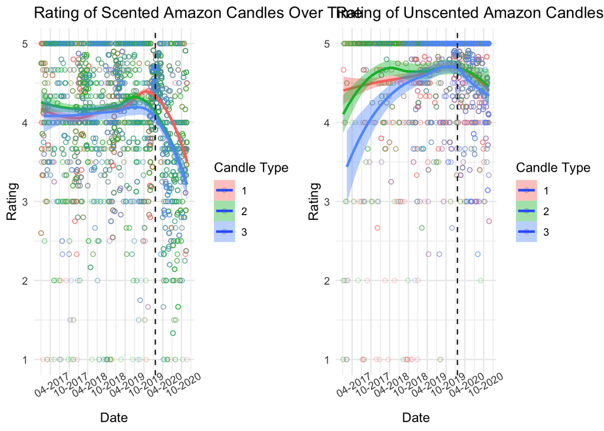

```r
plot1 <-
  scented %>%
  filter(Date > as.Date("2017-01-01")) %>%
  group_by(Date) %>%
  mutate(mean_rating= mean(Rating)) %>%
  ggplot(
    aes(x=as.Date(Date), y=mean_rating,
        shape=as.factor(CandleID),
        color=as.factor(CandleID),
        fill= as.factor(CandleID))) +
         geom_point(alpha=.3, shape=1) +
      scale_x_date(date_breaks = "6 months", date_labels = "%m-%Y") +
  geom_smooth(method = "loess") +
  geom_vline(xintercept = as.numeric(as.Date("2020-01-20")), linetype="dashed")+
  theme_minimal()+
  scale_fill_discrete(name="Candle Type")+
  guides(color=FALSE)+
  scale_y_continuous(name="Rating")+
  xlab("Date") +
  theme(axis.text.x = element_text(angle = 30))+
  ggtitle("Rating of Scented Amazon Candles Over Time")

plot2 <-
  unscented %>%
  filter(Date > as.Date("2017-01-01")) %>%
  group_by(Date) %>%
  mutate(mean_rating= mean(Rating)) %>%
  ggplot(
    aes(x=as.Date(Date), y=mean_rating,
        shape=as.factor(CandleID),
        color=as.factor(CandleID),
        fill= as.factor(CandleID))) +
         geom_point(alpha=.3, shape=1) +
      scale_x_date(date_breaks = "6 months", date_labels = "%m-%Y") +
  geom_smooth(method = "loess") +
  geom_vline(xintercept = as.numeric(as.Date("2020-01-20")), linetype="dashed")+
  theme_minimal()+
  scale_fill_discrete(name="Candle Type")+
  guides(color=FALSE)+
  scale_y_continuous(name="Rating")+
  xlab("Date") +
  theme(axis.text.x = element_text(angle = 30))+
  ggtitle("Rating of Unscented Amazon Candles Over Time")

grid.arrange(plot1, plot2, ncol=2)
```

*Combined plot*

Now, the two datasets have been combined into one, so that the trend lines for scented and unscented candles can be plotted on the same graph.

```r
candles_full <- bind_rows(
    scented = scented,
    unscented = unscented,
    .id = "Scented"
)
```

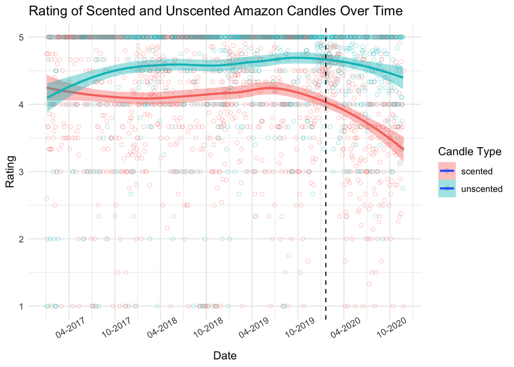

```r
candles_full %>%
  filter(Date > as.Date("2017-01-01")) %>%
  group_by(Date, Scented) %>%
  summarize(mu = mean(Rating)) %>%
  ggplot(
    aes(x=as.Date(Date), y=mu,
        shape=as.factor(Scented),
        color=as.factor(Scented),
        fill= as.factor(Scented))) +
         geom_point(alpha=.3, shape=1) +
      scale_x_date(date_breaks = "6 months", date_labels = "%m-%Y") +
  geom_smooth(method = "loess") +
  geom_vline(xintercept = as.numeric(as.Date("2020-01-20")), linetype="dashed")+
  theme_minimal()+
  scale_fill_discrete(name="Candle Type")+
  guides(color=FALSE)+
  scale_y_continuous(name="Rating")+
  xlab("Date") +
  theme(axis.text.x = element_text(angle = 30))+
  ggtitle("Rating of Scented and Unscented Amazon Candles Over Time")
```

I find this combined figure easier to interpret than the side by side figures because we can very explicitly see how drastically the ratings in scented candles dropped compared to unscented. Further, I think it’s simpler to look at two trend lines rather than the six that are presented in the two side-by-side plots. One pro of the side-by-sides is that we can see the trend lines for each of the top three candles, which is very useful information, but the combined plot very clearly shows us what we are interested in.

*Proportion of reviews mentioning “no scent”*

Use the scented candles database and make one more plot showing:

1. For **each month in 2019 and 2020**,
2. On the x axis, month and year
3. On the y axis, the **proportion of reviews** mentioning that the scented candles have no smell - Include both the mean (proportion) and a 95% confidence interval
4. Color the symbols by year (2019 vs 2020)

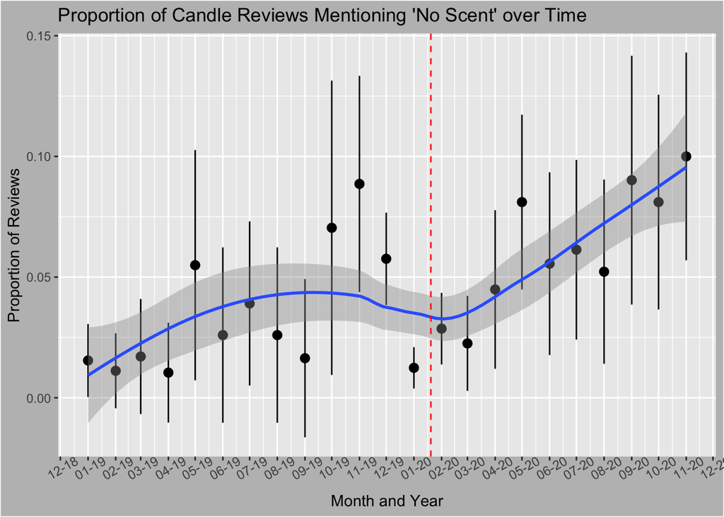

```r
scented$ScentReview <- str_no_scent(scented$Review)
scented$Date<-as.Date(scented$Date)

new_data<-scented %>%
  filter(Date >= as.Date("2019-01-01") & CandleID <= 3) %>%
  mutate(month = lubridate::floor_date(Date, "month")) %>%
  mutate(Review = str_no_scent(Review))

ggplot(new_data, aes(x = month, y = ScentReview)) +
  stat_summary(aes(y = ScentReview),fun.data = mean_cl_normal) +
  scale_x_date(date_breaks = "month", date_labels = "%m-%y") +
  guides(shape = FALSE) +
  scale_y_continuous(name = "Proportion of Reviews") +
  xlab("Month and Year")+
  geom_smooth(method = "loess") +
  theme(axis.text.x = element_text(angle = 30))+
  geom_vline(xintercept = as.numeric(as.Date("2020-01-20")),
             colour = "red",
             linetype = 2
             ) +
  ggtitle("Proportion of Candle Reviews Mentioning 'No Scent' over Time") +
  theme(plot.background = element_rect(fill = "gray"),
        axis.text.x = element_text(size = 9)
        )
```

Over time, the proportion of reviews mentioning no scent or lack of scent increased, with the slope really changing at the beginning of 2020, as indicated with the red dashed line.